# Data Visualization: `ggplot` part 2

## Other Aesthetics

There are lots of options for aesthetics. An aesthetic can be assigned to either numeric or categorical data. `fill` is a common grouping option; notice that an appropriate key is displayed when you use one of these options.

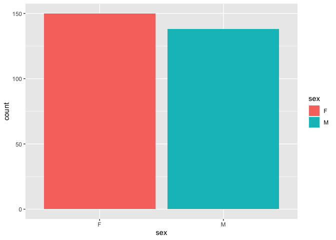

```r
elephants %>%
  ggplot(aes(x=sex, fill=sex))+geom_bar()
```

```r
#Just doing count, so fill=sex, bars will be color coded by sex
```

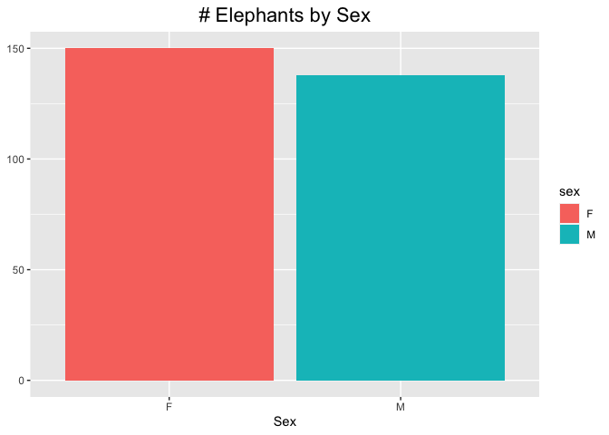

```r
elephants %>%
  ggplot(aes(x=sex, fill=sex))+geom_bar()+
  labs(title = "# Elephants by Sex",
       x = "Sex",
       y = NULL) +
  theme(plot.title = element_text(size = rel(1.5), hjust = 0.5))
```

```r
#Now adding the rest of the aesthetics, adjusting ex. Title, x, y as necessary
#y=NULL removes axis count altogether
```

`size` adjusts the size of points relative to a continuous variable.

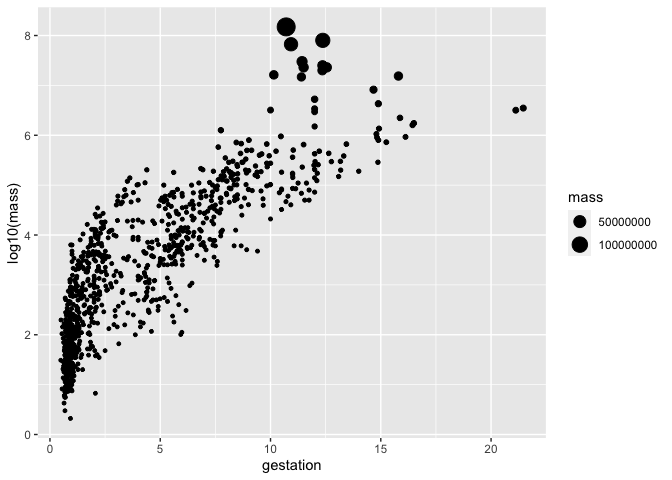

```r
life_history %>%
  ggplot(aes(x=gestation, y=log10(mass), size=mass))+
  geom_point(na.rm=T)
```

```r
#log10mass takes care of the big differences between mass
#Now there's a plot wher bigger individuals get bigger dot sizes
```

```r
#Some animals have gestation period of 20 months, which is a very long time, so filtering to see which animals those are
life_history %>%
  filter(gestation>20)
```

```
## # A tibble: 2 x 13
##   order family genus species   mass gestation newborn weaning wean_mass   afr
##   <chr> <chr>  <chr> <chr>    <dbl>     <dbl>   <dbl>   <dbl>     <dbl> <dbl>
## 1 Prob… Eleph… Elep… maximus 3.18e6      21.1 100039.    18          NA  127.
## 2 Prob… Eleph… Loxo… africa… 3.51e6      21.5  99006.    39.4    600000  148.
## # … with 3 more variables: max_life <dbl>, litter_size <dbl>,
## #   litters_year <dbl>
```

## Practice

Let’s end today’s lab by looking at the homerange data. By now, these should be very familiar to you.

```r
homerange <- read_csv(here("lab10", "data", "Tamburelloetal_HomeRangeDatabase.csv"))
names(homerange)
```

```
##  [1] "taxon"                      "common.name"
##  [3] "class"                      "order"
##  [5] "family"                     "genus"
##  [7] "species"                    "primarymethod"
##  [9] "N"                          "mean.mass.g"
## [11] "log10.mass"                 "alternative.mass.reference"
## [13] "mean.hra.m2"                "log10.hra"
## [15] "hra.reference"              "realm"
## [17] "thermoregulation"           "locomotion"
## [19] "trophic.guild"              "dimension"
## [21] "preymass"                   "log10.preymass"
## [23] "PPMR"                       "prey.size.reference"
```

1. Make a barplot that shows counts of ectotherms and endotherms. Label the axes, provide a title, and fill by `thermoregulation`.

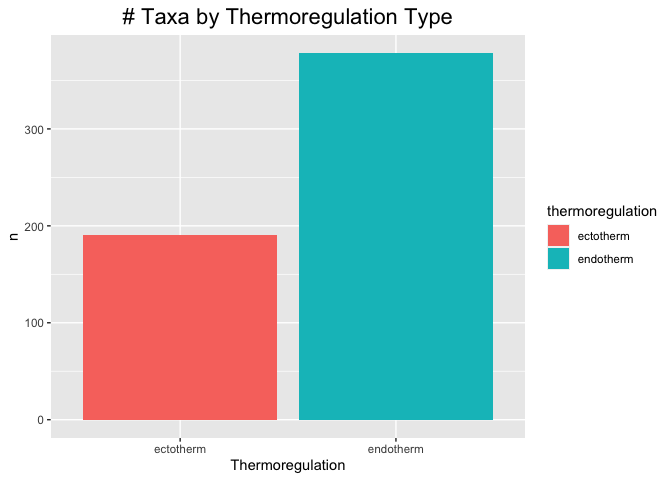

```r
homerange %>%
  ggplot(aes(x=thermoregulation, fill=thermoregulation))+
  geom_bar()+
  labs(title = "# Taxa by Thermoregulation Type",
       x = "Thermoregulation",
       y = "n") +
  theme(plot.title = element_text(size = rel(1.5), hjust = 0.5))
```

```r
#Don't need to have y because now you're doing a count
```

2. Make a scatterplot that compares log10.mass and homerange. Adjust the size of points by mass. Label the axes and provide a title.

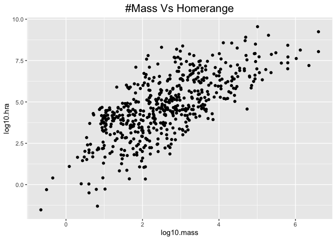

```r
homerange %>%
  ggplot(aes(x=log10.mass, y=log10.hra))+geom_point()+
  labs(title = "#Mass Vs Homerange",
       x = "log10.mass",
       y = "log10.hra") +
  theme(plot.title = element_text(size = rel(1.5), hjust = 0.5))
```

```r
#y=log10.hra is homerange data
```

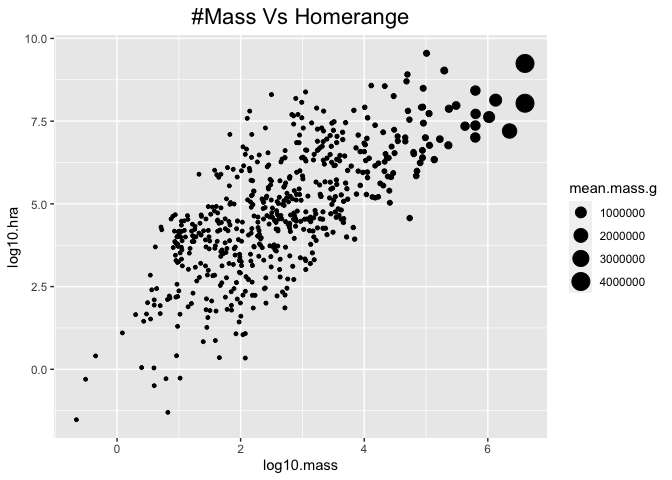

```r
#Can we adjust dot size by their mass?
homerange %>%
  ggplot(aes(x=log10.mass, y=log10.hra, size=mean.mass.g))+geom_point()+
  labs(title = "#Mass Vs Homerange",
       x = "log10.mass",
       y = "log10.hra") +
  theme(plot.title = element_text(size = rel(1.5), hjust = 0.5))
```

```r
#You can also adjust size by writing ex. size=0,5
```

## That’s it! Take a break and I will see you on Zoom!

–>[Home](https://jmledford3115.github.io/datascibiol/)